# Modelagem da ocorrência de terremotos por processos de poisson

Este estudo avalia a probabilidade de ocorrência de terremotos de magnitude maior ou igual a 6 ao redor do mundo por meio da modelagem de um Processo de Poisson Homogêneo. Para obter a taxa histórica com que ocorrem os sismos, foram utilizados dados do Serviço Geológico dos Estados Unidos (USGS) do período de 1990 a 2025. O período em questão foi escolhido devido à modernização dos sismógrafos ao fim dos anos 1980 e início dos anos 1990, que tornaram os aparelho de medição — com sua maioria tornando-se digitais, mais precisos. Para garantir uma das principais condições do modelo Poisson, a independência entre cada ocorrência, foi aplicado o algoritmo de Gardner e Knopoff para identificação e remoção de réplicas de sismos (*Declustering*). Outra condição essencial do modelo Poisson é que os tempos entre as ocorrências sigam uma distribuição exponencial, o que foi confirmado após a remoção das réplicas por meio dos testes de aderência de Kolmogorov-Smirnov e Cramer Von Mises, além de visualização gráfica com uso de histograma. A análise resultou em uma taxa estimada de $\lambda = 0,264$ terremotos por dia. Diante disse, foi conduzido um teste de hipóteses para avaliar a probabilidade de se ocorrerem 14 ou mais sismos durante um período de 30 dias (Junho de 2026), a fim de verificar se essa ocorrência distoava da taxa histórica. O modelo previa um valor esperado de $\mu = 7,92$ sismos nese período, enquanto o teste resultou em um p-valor de $p = 0,032$. Ao nível de significância de $5\%$, a hipótese nula foi rejeitada, e assumiu-se que o número de terremotos de magnitude $\ge 6$ no mês de Junho de 2026 ao redor do mundo foi estatisticamente maior do que a frequência esperada segundo a taxa histórica.

**Palavras-chave:** Processo de poisson; Sismos, Terremotos; Teste de hipóteses; Algoritmo de Gardner e Knopoff; Declustering.

# Introdução

Os sismos (ou terremotos), eventos naturais caracterizados por um tremor de terra em pequena ou larga escala, têm grande impacto socioeconômico e ambiental, podendo causar desde apenas um alerta até a destruição em massa de grandes áreas, incluindo casas, prédios, hospitais e outras estruturas de grande importância. Embora a física geológica possa ter seu nível de determinismo, os momentos em que sismos ocorrem em geral são considerados eventos probabilísticos, dada a complexidade de previsão e a variabilidade do sistema geológico como um todo. Em decorrência disso, é de grande importância desenvolver modelos quantitativos que permitam prever ou, ao menos, descrever e avaliar a periodicidade dos sismos e analisar se há alguma anomalia na frequência com que ocorrem. Com esse fim, um processo de poisson se torna um método de grande valia no contexto da sismologia.

O Processo de Poisson Homogêneo é um clássico modelo conhecido por sua utilidade em descrever a contagem de eventos raros e independentes em um intervalo de tempo contínuo. Para que esse modelo seja aplicado com precisão, é necessário cumprir algumas premissas: (Ross 1996)

- **Independência entre os eventos:** A ocorrência de um sismo não altera — seja para mais ou para menos, a probabilidade de ocorrência de outro ocorrer no futuro.
- **Taxa de ocorrência** $(\lambda)$ **constante:** Ao longo do tempo, a taxa de ocorrência dos sismos não deve variar muito, ou seja, a frequência com que ocorrem os eventos deve ser aproximadamente a mesma a longo prazo.
- **Distribuição dos tempo entre eventos:** É necessário que os tempos entre eventos sucessivos sigam uma distribuição Exponencial.

A fim de obter resultados que possam contribuir para o estudo da sismologia, foi escolhido como objeto de estudo apenas os sismos com magnitude $\ge 6$, sendo caracterizados como fortes, segundo o Serviço Geológico dos Estados Unidos (USGS). Visto que sismos a partir dessa magnitude têm grande potencial de causar destruição em escala considerável, é essencial mapear a frequência com que os mesmos ocorrem.

Para obtenção dos dados e cálculo da taxa histórica de ocorrência dos sismos, que serviu como base para o estudo, foi escolhido o período de 1990 a 2025. Essa escolha se baseia no fato de que houve uma grande modernização dos sismógrafos ao fim da década de 1980 que, com a consolidação dos aparelhos de medição digitais, passaram a registrar eventos sísmicos com muito mais precisão (Ringler et al. 2022). Desse modo, diminui-se a chance de se obter uma taxa histórica menor do que a verdadeira já que, tendo menos precisão antes desse período, os sismógrafos analógicos poderiam não ser capazes de detectar parte considerável dos eventos ao redor do mundo, ocasionando numa pseudo-queda da taxa histórica, levando a uma conclusão enviesada por meio do teste de hipóteses.

Além disso, é essencial mencionar que terremotos em geral geram réplicas, isto é, terremotos posteriores que costumam ser menores que o abalo principal (Gardner e Knopoff 1974). Caso avaliássemos todos os eventos sísmicos que foram medidos, violaríamos a premissa de independência do processo de Poisson. Por isso, foi necessário limpar a base de dados e remover as réplicas dos terremotos, no entanto, identificar quais eventos são os principais e quais são as réplicas pode ser uma tarefa complexa, já que ao obter os dados não há uma categoria prévia para cada evento. Assim, foi utilizado o método de *Declustering* de Gardner e Knopoff (Gardner e Knopoff 1974), que funciona definindo uma janela espacial e temporal que serve como limite para diferenciar um abalo principal de um tremor posterior dependente do primeiro, a fim de identificar, mapear e remover as réplicas.

Por fim, este estudo teve o objetivo de responder à pergunta central: “A quantidade de sismos de magnitude $\ge 6$ observados no mês de Junho de 2026 pode ser considerada uma atividade esperada dentro da taxa histórica mundial, ou representa uma anomalia, isto é, segundo o modelo $\text{Poisson}(\mu = 7,92)$, a frequência observada é um desvio estatisticamente significativo?”.

# Metodologia

Além disso, vale mencionar que os sismógrafos do USGS captam tremores de terra como um todo, o que significa que experimentos de larga escala como testes de bombas nucleares podem causar algum tremor de terra próxima ao local de teste. Em vista disso, também foram removidos da base de dados sismos caracterizados como “explosões” e “explosões nucleares”, mantendo apenas os evento ditos como “terremotos”.

Para uma visualização gráfica realista dos terremotos ocorridos no período recente selecionado (Junho de 2026), foi feito um mapa com os terremotos ocorridos, fazendo uso dos pacotes `ggplot2`, `sf`, e `maps`. (Wickham 2016; Pebesma 2018; Becker et al. 2025)

Quanto à limpeza dos dados, um passo essencial na análise sismológica é remover a réplicas dos terremotos, isto é, abalos sismos, em geral menores, que ocorrem após e em decorrência do abalo principal, de modo que os dados atendam à premissa de independência do Processo de Poisson. Para isso, foi usado o algoritmo de *Declustering*, criado por (Gardner e Knopoff 1974). Este método funciona definindo limites espaciais e temporais para cada sismo, de modo que possa identificar os abalos seguintes como sendo réplicas ou não. Se um abalo que ocorreu após o sismo principal estiver dentro do limite de distância e de tempo calculados pelo algoritmo de *Declustering*, ele é considerado uma réplica, caso contrário, é categorizado como um outro abalo principal.

Os limites calculados pelo algoritmo pode de *Declustering* pode ser definido como:

$$D(M) = 10^{0,1238 \cdot M +
0,983}$$

$$T(M) = \begin{cases} 10^{0,5409 \cdot M
- 0,547}, & \text{se } M < 6,5 \\ 10^{0,032 \cdot M + 2,738},
& \text{se } M \ge 6,5 \end{cases}$$

em que $D(M)$ representa o limite de espacial (em km), $T(M)$ representa o limite temporal (em dias) e $M$ é a magnitude do sismo em questão. De modo que há duas possibilidades de cálculo para o limite tempora, a depender da magnitude, visto que os sismos comportam-se de maneira diferente nesse faixa.(Gardner e Knopoff 1974)

Para implementação do algoritmo, foi feita uma função manual usando a linguagem **R**. A função de *Declustering* funciona da seguinte maneira:

- **Ordenação:** O conjunto de dados é inicialmente ordenando em ordem decrescente de magnitude $M$, assegurando que os maiores sismos sejam analisados primeiro, evitando que uma réplica de menor magnitude classifique o abalo principal como réplica. A princípio, todos os sismos são classificados como não sendo réplicas.
- **Avaliação dos limites:** Para cada sismo $i$ não classificado como réplica, calcula-se os limites $D(M_i)$ e $D(T_i)$. A seguir, o algoritmo seleciona “candidatos”, os sismos que ocorreram posteriormente ao sismo atual $i$.
- **Cálculo da distância:** Para cada candidato $j$ selecionado, calcula-se a distância entre as coordenadas geográficas $(\text{longitude}_i, \text{latitude}_i)$ e $(\text{longitude}_i, \text{latitude}_j)$ a partir da fórmula de Haversine (Sinnott 1984) pelo pacote `geosphere` (`geosphere::distHaversine)` (Hijmans 2026), que é a menor distância entre dois pontos na superfície de uma esfera, já que a Terra é aproximadamente esférica.
- **Classificação e remoção:** Se a distância for menor ou igual a $D(M_i)$, o sismo $j$ é classificado como réplica e removido das iterações seguintes na função.
- **Nova base de dados**: Por fim, filtra a base de dados original e cria-se uma nova mantendo apenas os abalos sísmicos que não foram classificados com réplica, garantindo a independência entre eventos exigida pelo Processo de Poisson.

O método usado para modelagem dos dados foi o Processo de Poisson Homogêneo (PPH), que é frequentemente utilizado para contagem de eventos ao longo do tempo. Um PPH pode ser descrito pela seguinte função de probabilidade: (Ross 1996)

$$P(N(T) = k) = \frac{e^{-\mu} \cdot
\mu^k}{k!},\quad k = 0,1,2...$$

onde $P(N(T) = k)$ representa a probabilidade de ocorrerem $k$ eventos em um período de tempo de $T$ dias. O parâmetro $\mu = \lambda \cdot T$ é a quantidade de ocorrências esperada no tempo $T$, e $\lambda$ é a taxa de ocorrência dos eventos por dia. A taxa diária $\lambda$ foi estimada calculando-se a quantidade média diária de terremotos a partir dos dados históricos.

Além disso, para o Procesos de Poisson ser válido, o tempo $t$ entre eventos sucessivos deve seguir uma distribuição Exponencial. Uma distribuição Exponencial pode ser definida pela seguinte função densidade de probabilidade: (Ross 1996)

$$f(t) = \lambda e^{-\lambda
t}$$

em que $t$ é o tempo entre eventos sucessivos e o parâmetro $\lambda$ pode ser obtido a partir do seu Estimador de Máxima Verossimilhança (EMV): (Casella e Berger 2002)

$$L(\lambda) = \prod \lambda e^{-\lambda
t}
\\ L(\lambda) = \lambda^n e^{-\lambda \sum t_i}
\\ l(\lambda) = n\ln(\lambda) - \lambda \sum t_i$$

$$\frac{\partial}{\partial\lambda}
l(\lambda) = \frac{\partial}{\partial\lambda} \left[ n \ln(\lambda) -
\lambda \sum t_i \right]$$

$$\frac{\partial}{\partial\lambda}
l(\lambda) = \frac{n}{\lambda} - \sum t_i$$

$$\frac{n}{\lambda} = \sum t_i
\\ \hat{\lambda} = \frac{n}{\sum t_i}$$

isto é, o Estimador de Máxima Verossimilhança de $\lambda$ é o inverso da média. Assim, temos:

$$\hat{\lambda} =
\frac{1}{\bar{T}}$$

A fim de validar a premissa, foram realizados testes de bondade de ajuste (*goodness-of-fit*). Inicialmente, foi feita uma visualização gráfica inicial via histograma, além de uma comparação da função de distribuição acumulada empírica dos tempos entre eventos sucessivos via função `ecdf()` em comparação com a curva teórica esperada de uma distribuição Exponencial. Após isso, foram utilizados os testes de aderência de Kolmogorov-Smirnov (KS) e Cramér-Von Mises (CVM), ambos são testes que avaliam a discrepância entre a função distribuição empírica $F_n(x)$ e a função distribuição acumulada teórica $F_X(x)$. (Ferreira 2025)

O teste de Kolmogorov-Smirnov utiliza como estatística de teste a maior diferença (supremo) absoluta entre a distribuição empírica e a teórica:

$$D_n = \sup_x \vert{}F_n(x) -
F_X(x)\vert{}$$

Para o cálculo computacional, a estatística $D_n$ é dada por: (Ferreira 2025)

$$D_n = \max \left\{ \max_{1 \le i \le n}
\left[ \frac{i}{n} - F_X(X_{(i)}) \right], \max_{1 \le i \le n} \left[
F_X(X_{(i)}) - \frac{i-1}{n} \right] \right\}$$

Como é um teste que não exige conhecimento prévio da distribuição (*distribution-free*), a estatística independe da $F_X$ original, desde que a distribuição original seja contínua e explícita em sob a hipótese nula.

Além disso, aplicou o método de Cramér-Von Mises (CVM), baseado na função de distribuição empírica. A estatística de teste é dada por:

$$W^2 = \frac{1}{12n} + \sum_{i=1}^{n}
\left( p_{(i)} - \frac{2i-1}{2n} \right)^2$$

em que $p_{(i)} = F_0(X_{(i)})$ representa a probabilidade acumulada teórica das estatísticas de ordem $X_{i}$ da amostra. (Ferreira 2025)

Por meio dos testes de aderência citados, testamos as seguintes hipóteses:

$$\begin{cases}H_0: \text{Os tempos entre
eventos sucessivos seguem uma distribuição exponencial com taxa }
\lambda
\\ H_1: \text{Os tempos entre eventos sucessivos não seguem uma
distribuição exponencial com taxa } \lambda \end{cases}$$

Por fim, foi feito um teste de hipóteses seguindo o modelo Poisson para verificar se a quantidade de sismos observada no mês de Junho de 2026 estava dentro da taxa histórica esperada, ou se poderia ser classificada como um comportamento sismológico anômalo. Assim, foram testadas as seguintes hipóteses:

$$\begin{cases} H_0: \text{A quantidade de
sismos} \text{ no périodo avaliado segue a taxa histórica esperada}
\\ H_1: \text{O número de sismos} \text{ no período avaliado é
estatisticamente superior à taxa histórica} \end{cases}$$

Seguindo um Processo de Poisson Homogêneo (PPH), temos o seguinte teste: (Ross 1996)

$$P(N(T) \ge k) = 1 - P(N(T) < k) = 1 -
\sum_{n=0}^{k-1} \frac{e^{-\mu} \mu^n}{n!}$$

onde é calculada a probabilidade de se observar $k$ ou mais eventos em um período de tempo $T$, segundo uma média (valor esperado) de $\mu$ eventos no período $T$. No entanto, para calcular essa probabilidade seria necessário somar de $k \text{ até } \infty$, o que na prática é impossível. Para resolver este problema, é calculada a probabilidade complementar, isto é, $1 - \text{ o somatório das probabilidade de ocorrerem de 0 até k - 1 eventos}$. (Ross 1996)

Neste caso, o p-valor pode ser calculado facilmente pelo pacote nativo do R `stats (stats::ppois)`. (R Core Team 2025)

Em todos os testes de hipóteses, foi adotado um nível de significância de $5\%$, isto é, $\alpha = 0,05$. Desse modo, a hipótese nula seria rejeitada nos casos em que o p-valor $p$ resultante do teste fosse menor que o nível de significância $\alpha = 0,05$.

# Resultados e discussão

### Sismos recentes (Junho de 2026)

Na tabela abaixo, pode-se ver os dados dos sismos ocorridos durante o mês de Junho de 2026, após removidas as réplicas por meio do algoritmo de *Declustering* de Gardner e Knopoff. Inicialmente eram 29 eventos, que tornaram-se 14 após a remoção das réplicas. É Importante citar que caso não fossem removidas as réplicas, a base de dados teria mais que o dobro de eventos registrados, o que faria parecer que é um evento extremamente improvável pela quantidade, quando na verdade, em média, registrou-se aproximadamente uma réplica para cada abalo sísmico principal. Além disso, também quebraria a premissa de independência entre os eventos exigida pelo modelo Poisson.

| Data | Latitude | Longitude | Profundidade (km) | Magnitude | Local |
| --- | --- | --- | --- | --- | --- |
| 2026-06-01 22:12:36 | 39.2548 | 15.7869 | 243.000 | 6.2 | 23 km WSW of San Lucido, Italy |
| 2026-06-07 10:41:56 | 49.9805 | 157.2497 | 18.000 | 6.0 | 111 km SE of Severo-Kuril’sk, Russia |
| 2026-06-07 23:37:41 | 5.5994 | 125.0560 | 56.991 | 7.8 | 25 km SW of Kablalan, Philippines |
| 2026-06-08 18:00:27 | 22.7910 | -85.0919 | 26.000 | 6.1 | 99 km WNW of Mantua, Cuba |
| 2026-06-10 00:44:20 | -49.6503 | 164.0868 | 10.000 | 6.0 | Auckland Islands, New Zealand region |
| 2026-06-15 09:18:36 | 6.2076 | 126.7773 | 84.000 | 6.2 | 68 km ESE of Pondaguitan, Philippines |
| 2026-06-16 03:27:44 | -1.1245 | 120.1842 | 11.000 | 6.7 | 42 km SE of Palu, Indonesia |
| 2026-06-16 09:06:55 | 37.8880 | 95.4919 | 10.000 | 6.3 | 262 km SSE of Dunhuang, China |
| 2026-06-17 18:56:58 | -0.5458 | -20.0163 | 10.000 | 6.6 | central Mid-Atlantic Ridge |
| 2026-06-19 06:51:28 | 52.7342 | 160.8830 | 10.000 | 6.0 | 156 km ESE of Petropavlovsk-Kamchatsky, Russia |
| 2026-06-24 22:04:34 | 10.4085 | -68.5571 | 27.588 | 7.2 | 21 km ENE of San Felipe, Venezuela |
| 2026-06-24 22:30:12 | 40.2515 | 142.1614 | 34.000 | 6.9 | 33 km ENE of Noda, Japan |
| 2026-06-27 13:34:52 | 36.4806 | 70.7309 | 199.000 | 6.1 | 43 km SSW of Jurm, Afghanistan |
| 2026-06-30 19:45:39 | 24.8088 | -108.8902 | 10.000 | 6.0 | 75 km SSW of El Progreso, Mexico |

Além disso, abaixo pode-se ver uma visualização em mapa, o que facilita a entender onde ocorreram os terremotos e com que intensidade e profundidade.

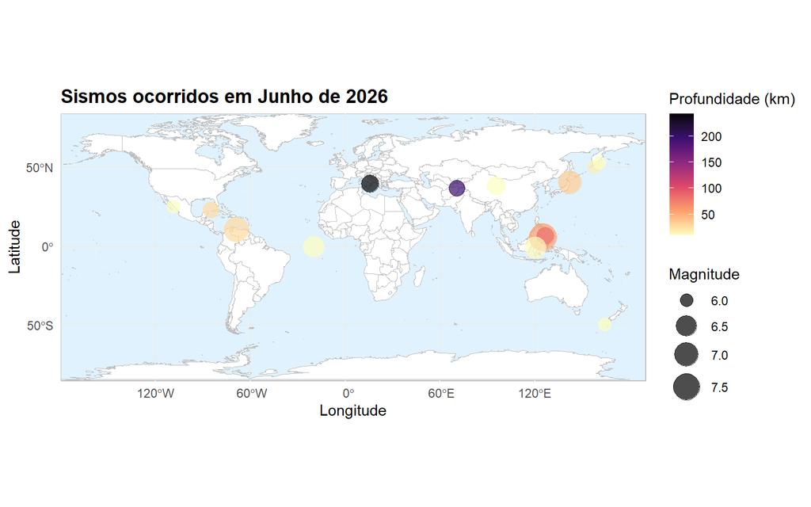

### Verificação da distribuição dos tempos entre eventos sucessivos

A partir do Estimador de Máxima Verossimilhança (EMV) de $\lambda$:
$$\hat{\lambda} = \frac{1}{\bar{T}}$$

foi encontrado um valor estimado de $\hat{\lambda} = 0,264$.

O valor de $\hat{\lambda} = 0,264$ representa a frequência média esperada de terremotos por dia no mundo. Essa taxa indica uma média aproximada de $1$ terremoto (abalo principal) a cada $3,78$ dias segundo o Processo de Poisson em questão. Assim, tem-se que o tempo de espera entre dois terremotos — calculado, no caso Exponencial, como o inverso da taxa é, em média, de $3,78$ dias.

Abaixo, tem-se o histograma dos tempos entre eventos sucessivos em comparação com a curva Exponencial teórica, o encaixe praticamente exato indica que a distribuição Exponencial se enquadra bem aos dados.

O fato de a maior densidade estar próxima de zero no gráfico, indica que a maior parte dos sismos subsequentes tendem a acontecer em um curto período de tempo, em média, dentro de $3,78$ dias. A assimetria positiva (cauda longa à direita) presente na distribuição Exponencial indica que conforme o tempo passa, a probabilidade de ocorrência de outro evento principal tende a diminuir, o que pode ser percebido nos longos período sem abalos sísmicos que costumam ocorrer.

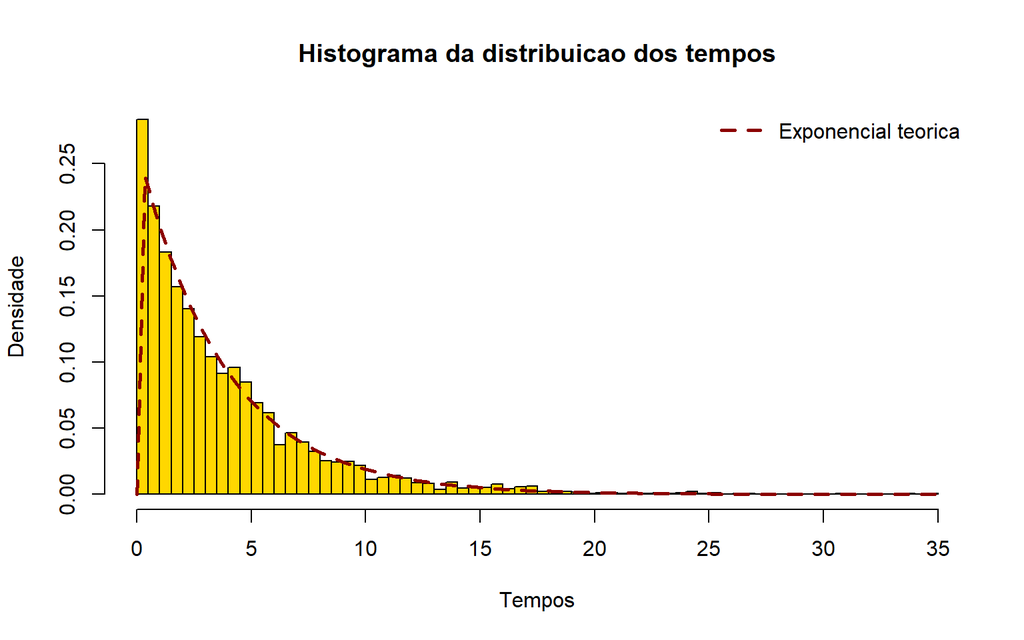

A seguir, temos a função de distribução acumulada empírica, via função nativa do R `stats::ecdf()` (R Core Team 2025), em comparação com a curva da distribuição acumulada da Exponencial. O ótimo encaixe também indica que os tempos entre eventos sucessivos segue uma distribuição Exponencial.

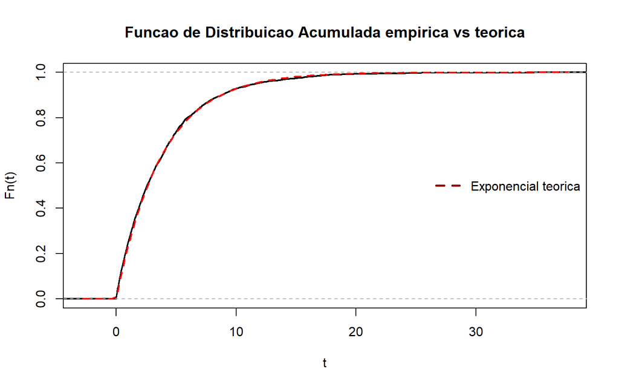

### Testes de aderência

Abaixo, temos os resultados dos testes de aderência realizados para comparar os tempos entre eventos sucessivos a uma distribuição Exponencial. Ao nível de significância de $5\%$, não rejeitamos a hipótese nula, haja visto os p-valores serem ambos maiores que $\alpha = 0,05$. O fato de não só as representações gráfica indicarem um bom ajuste dos tempos à distribuição Exponencial, mas também ambos os testes concordarem nos dá uma maior confiança de que os dados dos tempos de fato são exponenciais.

| Teste | Estatistica | P-valor | Decisao |
| --- | --- | --- | --- |
| Kolmogorov-Smirnov | 0.0211 | 0.0908 | Nao rejeitar H0 |
| Cramer-Von Mises | 0.4015 | 0.0716 | Nao rejeitar H0 |

### Teste de hipóteses via modelo Poisson

Segundo o que foi visto na seção de metodologias, temos, para um teste de hipóteses Poisson:

$$P(N(T) \ge k) = 1 - P(N(T) < k) = 1 -
\sum_{n=0}^{k-1} \frac{e^{-\mu} \mu^n}{n!}$$

Assim, foram testadas as seguintes hipóteses:

$$\begin{cases} H_0: \text{A taxa de
ocorrência no mês analisado é igual à taxa histórica esperada }\ (\mu =
7,9178)
\\ H_1: \text{A taxa de ocorrência no mês analisado é superior à taxa
histórica esperada }\ (\mu > 7,9178) \end{cases}$$

Para o teste segundo o modelo Poisson, foram utilizados:

- $\lambda = 0,2639269$ a taxa de terremotos ocorridos por dia
- $T = 30$ como sendo o período de tempo analisado (mês de Junho de 2026)
- $\mu = \lambda \cdot T = 0,2639269 \times 30 = 7,917807$ que representa a quantidade de sismos esperada no período $T$
- $k = 14$ é o número de sismos ocorridos durante o período $T$ com magnitude $M \ge6$

$$P(N(T) \ge 14) = 1 - P(N(T) < 14) = 1
- \sum_{n=0}^{14-1} \frac{e^{-7,917807}\times
7,917807^n}{n!}$$

Com a função `ppois` citada anteriormente, foi obtido um p-valor de $p = 0,0318$. Ao nível de significância de $5\%$, rejeitou-se a hipótese nula, e concluiu-se que a frequência de terremotos de magnitude $M \ge 6$ observada no mês de Junho de 2026 foi anormalmente maior do que o esperado, segundo a taxa histórica.

Após analisar os resultados, é importante ressaltar que o cenário poderia ser diferente caso os dados utilizados abrangessem todo o período de 1900 a 2025, já que provavelmente haveria menos sismos detectados e resultaria numa taxa de ocorrência menor. Devido a essas possíveis “lacunas” nos dados, poderia acontecer que os tempos entre os eventos registrados não seguisse uma distribuição Exponencial, quebrando a premissa do Processo de Poisson.

Além disso, apesar de o modelo Poisson e a distribuição Exponencial terem se ajustado tão bem aos dados, este estudo não nos dá a capacidade de prever ocorrências de sismos, mas apenas estimar a taxa com que ocorrem e a quantidade esperada dentro de um período de tempo $T$. A magnitude selecionada como $M \ge 6$ também poderia mudar o resultado, já que sismos mais fracos são muito mais frenquentes, o que poderia criar um viés de confusão se fosse incluídos na análise.

# Conclusão

Este estudo teve como objetivo verificar a capacidade de adequação de um Modelo de Poisson e da distribuição Exponencial na análise da frequência e do tempo entre as ocorrências de abalos sísmicos ao redor do mundo. Os métodos comprovaram de forma empírica que, após os devidos tratamentos dos dados, a ocorrência de sismos podem ser precisamente descritas por um Processo de Poisson Homogêneo.

O resultados encontrados deixaram claro a importância da aplicação de um algoritmo de remoção de réplicas, como o *Declustering* de Gardner e Knopoff, usado para garantir a independência entre cada abalo principal e a exponencialidade entre os tempos de ocorrência desses eventos. Com isso, foi estimada uma taxa média de $\lambda = 0,2639$ eventos por dia, o que leva a um tempo de espera de aproximadamente $3,78$ dias entre abalos principais sucessivos.

Com uso de visualizações gráficas, construção da função de distribuição acumulada empírica e teórica, e testes de aderência, verificou-se a adequação deste parâmetro à distribuição Exponencial ao nível de significância de $5\%$, com p-valores de $p = 0,0908\ \text{ e }\ p=0,0716$. Após isso, o teste de hipóteses por meio do modelo de Poisson identificou com precisão a baixa probabilidade de ocorrer 14 terremotos de magnitude $M \ge 6$ em um período de 30 dias segundo a taxa histórica calculada, comprovando a capacidade do modelo em detectar eventos improváveis ao longo do tempo.

Por fim, o modelo mostrou-se preciso e útil para a caracterização de eventos sísmicos ao redor de todo o mundo, embora tenha limitações devido à qualidade da base de dados original, principalmente em se tratando de registros mais antigos, anteriores à modernização e digitalização dos aparelhos de medição. Assim, para futuros estudos que visem uma análise mais completa, sugere a utilização de modelos mais complexos e flexíveis que lidem melhor com o problema da dependência das réplicas, como a distribuição de Weibull.

# Apêndice

Nesta seção, encontra-se todo o código utilizado para realização do estudo.

### Obtenção dos dados

```r
historicos <- read.csv('https://earthquake.usgs.gov/fdsnws/event/1/query?format=csv&starttime=1990-01-01&endtime=2025-12-31&minmagnitude=6.0')

recentes <- read.csv('https://earthquake.usgs.gov/fdsnws/event/1/query?format=csv&starttime=2026-06-01&endtime=2026-08-01&minmagnitude=6.0')
```

### Tratamento de dados

Note que o uso da função `remover_replicas('dataframe')` deve ser feito apenas após a criação da mesma, na subseção seguinte.

```r
historicos_limpos <- remover_replicas(historicos)
historicos_limpos <- historicos_limpos %>% relocate(time_limpo, .before = 2) #colocar a coluna no comeco do df
historicos_limpos <- historicos_limpos %>% #manter apenas terremotos (exlcui tremores causados por explosoes)
  filter(type == 'earthquake')

cat('foram removidas', nrow(historicos) - nrow(historicos_limpos), 'replicas, diminuindo o dataframe de', nrow(historicos), 'linhas (sismos) para', nrow(historicos_limpos))

historicos_limpos$ano <- substr(historicos_limpos$time, start = 1, stop = 4) #criando coluna de ano
historicos_limpos$ano <- as.numeric(historicos_limpos$ano)

historicos_limpos <- historicos_limpos[order(historicos_limpos$time_limpo), ] #ordenando do mais antigo pro mais recente

rownames(historicos_limpos) <- NULL #resetar os indices das linhas

saveRDS(historicos_limpos, file = 'historicos_limpos.rds') #salvando o dataframe no formato .rds para manter os formatos

#################################################################

recentes_limpos <- remover_replicas(recentes)
recentes_limpos <- recentes_limpos %>% relocate(time_limpo, .before = 2) #colocar a coluna no comeco do df

recentes_limpos <- recentes_limpos %>% #manter apenas terremotos (exlcui tremores causados por explosoes)
  filter(type == 'earthquake')

recentes_limpos <- recentes_limpos %>%
  filter(time_limpo <= '2026-07-01')

recentes_limpos <- recentes_limpos[order(recentes_limpos$time_limpo), ] #ordenando do mais antigo pro mais recente

rownames(recentes_limpos) <- NULL #resetar os indices das linhas

cat('foram removidas', nrow(recentes) - nrow(recentes_limpos), 'replicas, diminuindo o dataframe de', nrow(recentes), 'linhas (sismos) para', nrow(recentes_limpos))

#saveRDS(recentes_limpos, file = 'recentes_limpos.rds') #salvando o dataframe no formato .rds para manter os formatos
```

### Aplicação do algoritmo de *Declustering*

Para implementação da função abaixo, foi feito uso do modelo de inteligência artificial Gemini (Google 2026) como ferramento de auxílio para construção do código.

```r
library(geosphere)
library(lubridate)
library(dplyr)

remover_replicas <- function(df){
  df$time_limpo <- as.POSIXct(df$time, format="%Y-%m-%dT%H:%M:%OSZ", tz="UTC") #conversao de data e hora para um formato compreensível pelo R
  df$is_replica <- FALSE #coluna que diz se um sismo é classificado como réplica ou não

  df <- df[order(-df$mag), ] #ordenando os dados em ordem decrescente de magnitude
  n <- nrow(df)

  for(i in 1:(n - 1)){ #o algoritmo verifica até a penúltima linha, visto que a última não possui mais dados após ela para comparar
    if(df$is_replica[i]) next #se for TRUE na coluna is_replica, o algoritmo ignora e vai para o próximo

    #formulas de gardner e knopoff para a magnitude atual (i) do loop for
    M <- df$mag[i]
    D_km <- 10^(0.1238*M + 0.983)
    T_dias <- if(M < 6.5) 10^(0.5409*M - 0.547) else 10^(0.032*M + 2.738)

    #aplicacao (otimizada)
    candidatos <- which( #ao invés de varrer o dataframe por inteiro, apenas alguns candidatos serão analisados
      !df$is_replica & #o candidato não pode já ter sido classificado como réplica (is_replica == TRUE)
        df$time_limpo > df$time_limpo[i] & #o candidato deve ter ocorrido após o terremoto atual
        df$time_limpo <= df$time_limpo[i] + as.difftime(T_dias, units = "days") #o candidato deve estar dentro da janela de tempo calculada na fórmula de gardner e knopoff
    )

    for(j in candidatos){
      p1 <- c(df$longitude[i], df$latitude[i]) #coordenadas do evento principal atual
      p2 <- c(df$longitude[j], df$latitude[j]) #coordenadas do candidato atual
      dist_km <- distHaversine(p1, p2)/1000 #calcula a distância entre as coordenadas e converte para km

      if(dist_km <= D_km){ #se a distância estiver dentro do limite calculado pela fórmula de gardner e knopoff, o sismo em questão é classificado como réplica (is_replica == TRUE)
        df$is_replica[j] <- TRUE
      }
    }
  }
  #retorna somente as ocorrências que não são classificadas como réplica
  return(df[df$is_replica == FALSE, ])
}
```

### Construção do mapa

```r
library(ggplot2); library(sf); library(maps)

mundo <- st_as_sf(maps::map("world", plot = FALSE, fill = T)) #carrega os dados de mapas dos países do mundo e converte para o formato 'simple features', do pacote 'sf'

ggplot()+
  geom_sf(data = mundo, fill = 'white', color = 'gray')+ #renderiza o mapa espacial com alguns personalizações
  geom_point(
    data = recentes_limpos,
    aes(x = longitude, y = latitude, size = mag, color = depth),
    alpha = 0.7 #define a transparência dos pontos, permitindo ver os possíveis pontos sobrepostos
  )+
  scale_color_viridis_c(option = 'magma', direction = -1, name = 'Profundidade (km)')+ #escala de cor contínua que tende aos critérios de acessibilidade de daltonismo
  scale_size_continuous(range = c(4,9), name = "Magnitude")+ # ajusta a escala do tamanho dos pontos
  coord_sf(expand = F)+ #garante que o sistema de coordenadas seja corretamente mantido para dados do tipo 'sf'
  theme_minimal()+ #personalizações como título, nomes dos eixos, temas e cores
  labs(
    title = "Distribuição de terremotos (adicionar período de tempo)",
    x = 'Longitude', y = 'Latitude'
  )+
  theme(
    panel.background = element_rect(fill = '#e0f2fe', color = 'gray'),
    plot.title = element_text(face = 'bold', size = 13.5),
    legend.position = 'right'
  )
```

### Verificação da exponencialidade dos tempos

```r
#usando NA porque o primeiro registro não tem um que anteceda ele
df$tempo_entre_sismos <- c(NA, as.numeric(difftime(df$time_limpo[-1],
                                                   df$time_limpo[-nrow(df)],
                                                   units = 'days')))

tempos <- na.omit(df$tempo_entre_sismos) #vetor com os tempos, exlcuindo o NA
```

```r
lambda_estimado <- 1/mean(tempos) #estimativa da taxa

hist(tempos, breaks = 50, freq = F, col = 'gold') #criação do historama
curve(dexp(x, rate = lambda_estimado), col = 'darkred', lwd = 2.5, add = T) #adiciona a curva teórica da distribuição Exponencial com taxa lambda_esitimado

ks.test(tempos, 'pexp', rate = lambda_estimado) #aplica o teste Kolmogorov-Smirnov

library(goftest)
#creamer von mises
cvm.test(tempos, "pexp", rate = lambda_estimado) #aplica o teste Cramér-Von Mises

plot(ecdf(tempos), lwd = 2, main = 'Função de Distribuição Acumulada empírica vs teórica') #Criar o gráfico  da distribuição acumulada dos tempos
curve(pexp(x, rate = lambda_estimado), col = 'red', lwd = 2, lty = 2, add=T) #adiciona a curva da distribuição acumulada teórica da distribuição Exponencial com taxa lambda_esitimado
```

### Teste de hipóteses Poisson

```r
df_recentes <- readRDS('recentes_limpos.rds') #carrega os dados recentes limpos
df_historicos <- readRDS('historicos_limpos.rds') #carrega os dados historicos limpos

#o trecho abaixo divide a quantidade de terremotos pela quantidade de anos para obter a média anual
#e em seguida divide por 365 para obter uma média diária estimada (mesmo havendo anos bissextos
# a diferença é tão ínfima que praticamente não influenciaria os cálculo, sendo e diferença da ordem de 10^-3)
anos <- as.factor(df_historicos$ano)
n_terr_ano <- nrow(df_historicos)/nlevels(anos)
n_terr_dia <- n_terr_ano/365
mu <- n_terr_dia*30

p.valor <- ppois(q = 14 - 1, lambda = mu, lower.tail = FALSE) #calcula o p-valor
```

# Referências bibliográficas

Becker, Richard A., Allan R. Wilks, Ray Brownrigg, Thomas P. Minka, e Alex Deckmyn. 2025. *maps: Draw Geographical Maps*. https://doi.org/10.32614/CRAN.package.maps.

Casella, George, e Roger L. Berger. 2002. *Statistical Inference*. 2º ed. Duxbury Advanced Series / Cengage Learning.

Faraway, Julian, George Marsaglia, John Marsaglia, e Adrian Baddeley. 2021. *goftest: Classical Goodness-of-Fit Tests for Univariate Distributions*. https://doi.org/10.32614/CRAN.package.goftest.

Ferreira, Clécio da Silva. 2025. *Inferência Estatística Não-Paramétrica*. Departamento de Estatística - Universidade Federal de Juiz de Fora (UFJF).

Gardner, J. K., e L. Knopoff. 1974. “Is the sequence of earthquakes in Southern California, with aftershocks removed, Poissonian?” *Bulletin of the Seismological Society of America* 64 (5): 1363–67.

Google. 2026. *Gemini: Large Language Model*. https://gemini.google.com.

Grolemund, Garrett, e Hadley Wickham. 2011. “Dates and Times Made Easy with lubridate”. *Journal of Statistical Software* 40 (3): 1–25. https://www.jstatsoft.org/v40/i03/.

Hijmans, Robert J. 2026. *geosphere: Spherical Trigonometry*. https://doi.org/10.32614/CRAN.package.geosphere.

Pebesma, Edzer. 2018. “Simple Features for R: Standardized Support for Spatial Vector Data”. *The R Journal* 10 (1): 439–46. https://doi.org/10.32614/RJ-2018-009.

R Core Team. 2025. *R: A Language and Environment for Statistical Computing*. R Foundation for Statistical Computing. https://www.R-project.org/.

Ringler, A. T., R. E. Anthony, R. C. Aster, et al. 2022. “Achievements and prospects of global broadband seismographic networks after 30 years of continuous geophysical observations”. *Reviews of Geophysics* 60 (3): e2021RG000749. https://doi.org/10.1029/2021RG000749.

Ross, Sheldon M. 1996. *Stochastic Processes*. John Wiley & Sons.

Sinnott, Roger W. 1984. “Virtues of the Haversine”. *Sky and Telescope* 68 (2): 158.

U.S. Geological Survey. 2026. *Earthquake Hazards Program: Web Service API*. U.S. Department of the Interior. https://earthquake.usgs.gov/fdsnws/event/1/.

Wickham, Hadley. 2016. *ggplot2: Elegant Graphics for Data Analysis*. Springer-Verlag New York. https://ggplot2.tidyverse.org.

Wickham, Hadley, Romain François, Lionel Henry, Kirill Müller, e Davis Vaughan. 2023. *dplyr: A Grammar of Data Manipulation*. https://doi.org/10.32614/CRAN.package.dplyr.

Zhu, Hao. 2024. *kableExtra: Construct Complex Table with ’kable’ and Pipe Syntax*. https://doi.org/10.32614/CRAN.package.kableExtra.